# Adding Multiple Chart Series in Quantmod R

SW

2024-09-22

This document is based on a post on **stackoverflow** with the title [Adding Multiple Chart Series in Quantmod R](https://stackoverflow.com/questions/38136008/adding-multiple-chart-series-in-quantmod-r).

## Getting the data

We load the required package first:

```r
library(quantmod)
```

You can get multiple stocks by specifying the required stocks in a vector by `c()` function. Further, we can assign these variables in a created environment, named `data` below.

```r
tickers <- c('GLD', 'GDX')
data <- new.env()
getSymbols(tickers, src = 'yahoo', from = '1980-01-01', env = data)
```

However, you need to add `data$` before to read the data, for example:

```r
head(data$GDX)
```

```
##            GDX.Open GDX.High GDX.Low GDX.Close GDX.Volume GDX.Adjusted
## 2006-05-22    36.52    37.29   35.87     37.23     197100     32.19755
## 2006-05-23    37.75    39.22   37.75     37.96     620900     32.82887
## 2006-05-24    37.13    37.57   35.87     36.52     638600     31.58352
## 2006-05-25    37.18    38.32   36.98     38.32     367000     33.14021
## 2006-05-26    38.74    38.74   37.77     38.55     269400     33.33912
## 2006-05-30    39.50    39.72   38.11     38.17     559100     33.01049
```

## Creating multiple chart series

We use `chart_Series` to create multiple chart series:

```r
chart_Series(Cl(data$GLD))
add_TA(Cl(data$GDX), on = 1)
```

However, in RStudio, the above codes will produce two plots, one with only one series `GLD` and the second one has both series in the same plot. As a result, we need to assign the plot to a varaible first and print it the chart is completed.

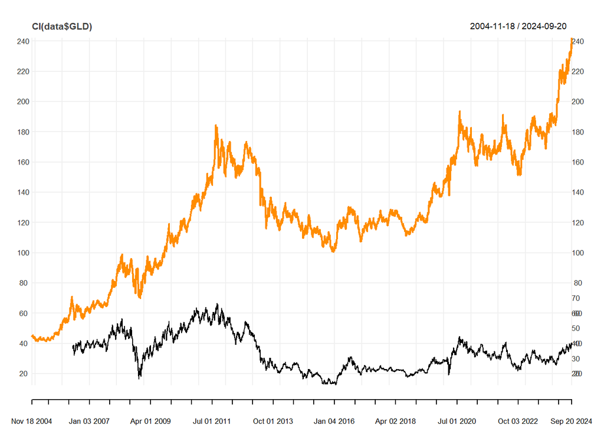

```r
Chart1 <- chart_Series(Cl(data$GLD))
Chart1 <- add_TA(Cl(data$GDX), on = 1)
Chart1
```

And then if you want RSI below in a sub panel, just add `add_RSI()`.

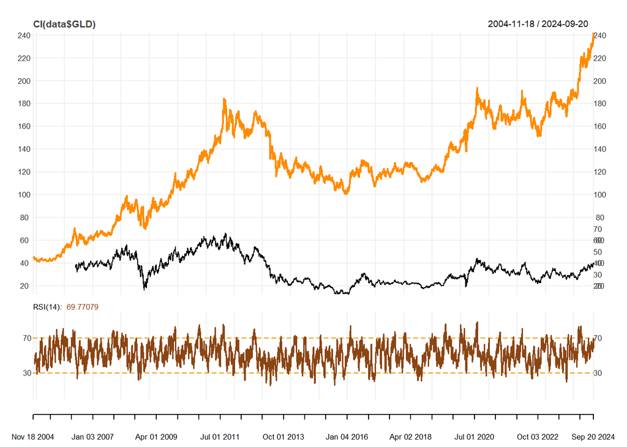

```r
Chart1 <- add_RSI()
Chart1
```

## Compare relative changes in multiple chart series

To see relative changes more easily, you can normalise your price series in many ways. This is a typical approach (using a 0 origin is what Google charts does). First we create the normalising function.

```r
# Create the normalising function
normalise_series <- function(xdat) xdat / coredata(xdat)[1]
```

We get one more stock price. In this time, we don’t assign it to the `data$` environment. As a result, when we retrieve the data, we just need to type the variable name.

```r
getSymbols("USO")
```

Further, we create a variable `window` which assign a period to it. In the following example, we assign `2013/` to the window variable, which means that we get the data from 2013 up to now. We can also assign, say `2013/2016-6` to the variable, which means we want the data from 2013 up to June of 2016.

```r
window <- "2013/"
```

We can also define a default chart line to chart_Series in `mytheme` object.

```r
# Define colour of default chart line to chart_Series in mytheme object
# which is passed to chart_Series
mytheme <- chart_theme()
mytheme$col$line.col <- "darkgreen"
```

Now, we can create the chart:

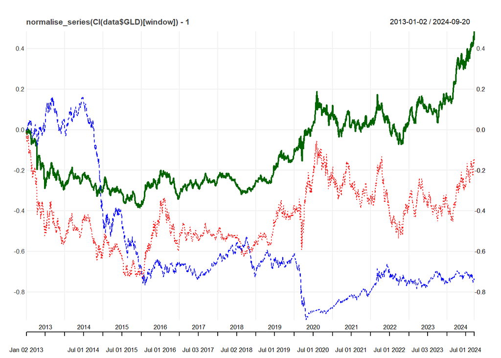

```r
Chart2 <- chart_Series(normalise_series(Cl(data$GLD)[window])-1, theme = mytheme)
Chart2 <- add_TA(normalise_series(Cl(data$GDX)[window]) -1, on = 1, col = "red", lty = 3)
Chart2 <- add_TA(normalise_series(Cl(USO)[window])-1, on = 1, col = "blue", lty = 2)
Chart2
```

Finally, we can add RSI below.

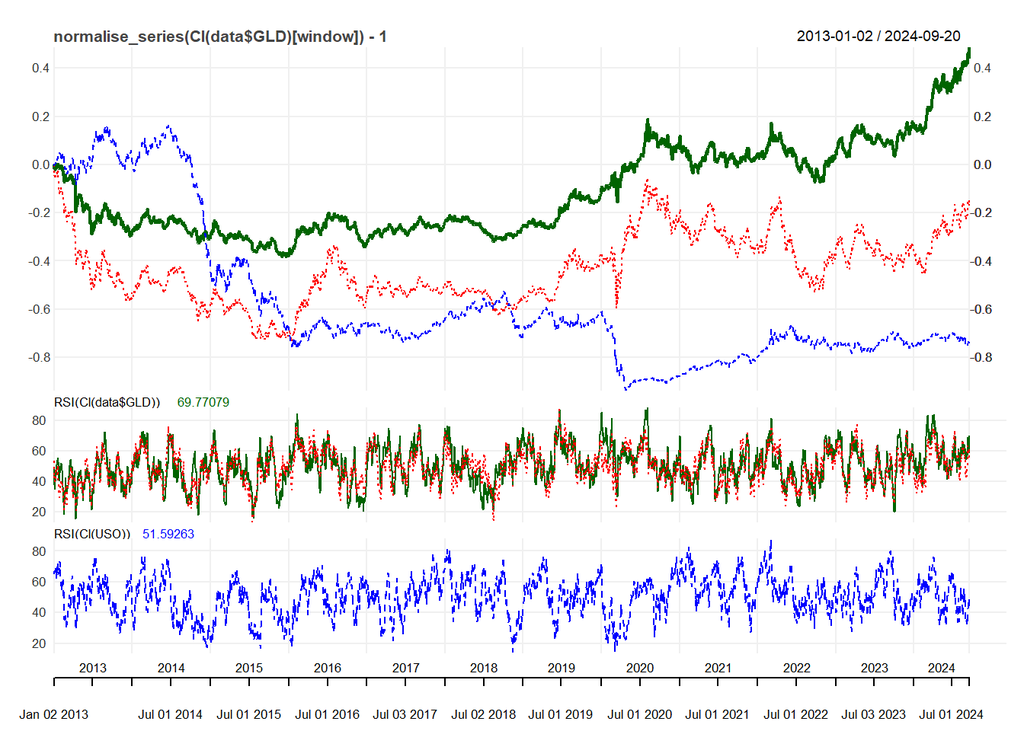

```r
Chart2 <- add_TA(RSI(Cl(data$GLD)), on = NA, col = "darkgreen")
Chart2 <- add_TA(RSI(Cl(data$GDX)), on = 2, col = "red", lty = 3)
# Or add RSIs on different subpanels to improve readability of charts:
Chart2 <- add_TA(RSI(Cl(USO)), on = NA, col = "blue", lty = 2)
Chart2
```